# Text analytics HW: Wikipedia

Anna Prades

4 juliol de 2015

In this assignment we will attempt to develop a vandalism detector that uses machine learning to distinguish between a valid edit and vandalism.

The data for this problem is based on the revision history of the page Language. Wikipedia provides a history for each page that consists of the state of the page at each revision. Rather than manually considering each revision, a script was run that checked whether edits stayed or were reverted. If a change was eventually reverted then that revision is marked as vandalism. This may result in some misclassifications, but the script performs well enough for our needs.

As a result of this preprocessing, some common processing tasks have already been done, including lower-casing and punctuation removal. The columns in the dataset are:

- Vandal = 1 if this edit was vandalism, 0 if not.
- Minor = 1 if the user marked this edit as a “minor edit”, 0 if not.
- Loggedin = 1 if the user made this edit while using a Wikipedia account, 0 if they did not.
- Added = The unique words added.
- Removed = The unique words removed.

Notice the repeated use of unique. The data we have available is not the traditional bag of words - rather it is the set of words that were removed or added. For example, if a word was removed multiple times in a revision it will only appear one time in the “Removed” column.

Load the data wiki.csv with the option stringsAsFactors=FALSE, calling the data frame “wiki”. Convert the “Vandal” column to a factor using the command wiki$Vandal = as.factor(wiki$Vandal).

How many cases of vandalism were detected in the history of this page?

```r
wiki <- read.csv("wiki.csv", stringsAsFactors = FALSE)
str(wiki)
```

```
## 'data.frame':    3876 obs. of  7 variables:
##  $ X.1     : int  1 2 3 4 5 6 7 8 9 10 ...
##  $ X       : int  1 2 3 4 5 6 7 8 9 10 ...
##  $ Vandal  : int  0 0 0 0 0 0 0 0 0 0 ...
##  $ Minor   : int  1 1 0 1 1 0 0 0 1 0 ...
##  $ Loggedin: int  1 1 1 0 1 1 1 1 1 0 ...
##  $ Added   : chr  "  represent psycholinguisticspsycholinguistics orthographyorthography help text all actions through human ethnologue relationsh"| __truncated__ " website external links" " " " afghanistan used iran mostly that farsiis is countries some xmlspacepreservepersian parts tajikestan r…
##  $ Removed : chr  " " " talklanguagetalk" " regarded as technologytechnologies human first" "  represent psycholinguisticspsycholinguistics orthographyorthography help all actions through ethnologue relationships linguis"| __truncated__ ...
```

```r
table(wiki$Vandal) #1815
```

```
##
##    0    1
## 2061 1815
```

```r
#Codi proposed in the solution -> gives the same result, but converts 1st Vandal as factor (why?)
wiki$Vandal = as.factor(wiki$Vandal)
table(wiki$Vandal) #1815
```

```
##
##    0    1
## 2061 1815
```

## Bag of words

We will now use the bag of words approach to build a model. We have two columns of textual data, with different meanings. For example, adding rude words has a different meaning to removing rude words. We’ll start like we did in class by building a document term matrix from the Added column. **The text already is lowercase and stripped of punctuation.** So to pre-process the data, just complete the following four steps:

1. Create the corpus for the Added column, and call it “corpusAdded”.
2. Remove the English-language stopwords.
3. Stem the words.
4. Build the DocumentTermMatrix, and call it dtmAdded.

If the code length(stopwords(“english”)) does not return 174 for you, then please run the line of code in this file, which will store the standard stop words in a variable called sw. When removing stop words, use tm_map(corpusAdded, removeWords, sw) instead of tm_map(corpusAdded, removeWords, stopwords(“english”)).

How many terms appear in dtmAdded?

```r
library(tm)
#Create a corpus
corpusAdded <- Corpus(VectorSource(wiki$Added))
corpusAdded = tm_map(corpusAdded, PlainTextDocument)
#Remove stopping words and stem the words
corpusAdded = tm_map(corpusAdded, removeWords, stopwords("english"))
strwrap(corpusAdded[[1]])
```

```
##  [1] "represent psycholinguisticspsycholinguistics"
##  [2] "orthographyorthography help text actions human ethnologue"
##  [3] "relationships linguistics regarded writing languages listing"
##  [4] "xmlspacepreservelanguages metaverse formal term philology common"
##  [5] "including phonologyphonology often ten list humans affiliation see"
##  [6] "computer speechpathologyspeech ways dialects please artificial"
##  [7] "written body quite hypothesis found alone refers language"
##  [8] "profanity study programming priorities rosenfelders"
##  [9] "technologytechnologies makes first among useful languagephilosophy"
## [10] "one sounds use area create phrases mark genetic basic families"
## [11] "complete sapirwhorfhypothesissapirwhorf talklanguagetalk"
## [12] "population animals science vocal can concepts called topics"
## [13] "locations numbers pathology different develop 4000 things ideas"
## [14] "grouped complex animal mathematics fairly literature"
## [15] "httpwwwzompistcom philosophy important meaningful"
## [16] "historicallinguisticsorphilologyhistorical semanticssemantics"
## [17] "patterns oral"
```

```r
corpusAdded = tm_map(corpusAdded, stemDocument)
strwrap(corpusAdded[[1]])
```

```
##  [1] "repres psycholinguisticspsycholinguist orthographyorthographi help"
##  [2] "text action human ethnologu relationship linguist regard write"
##  [3] "languag list xmlspacepreservelanguag metavers formal term philolog"
##  [4] "common includ phonologyphonolog often ten list human affili see"
##  [5] "comput speechpathologyspeech way dialect pleas artifici written"
##  [6] "bodi quit hypothesi found alon refer languag profan studi program"
##  [7] "prioriti rosenfeld technologytechnolog make first among use"
##  [8] "languagephilosophi one sound use area creat phrase mark genet"
##  [9] "basic famili complet sapirwhorfhypothesissapirwhorf"
## [10] "talklanguagetalk popul anim scienc vocal can concept call topic"
## [11] "locat number patholog differ develop 4000 thing idea group complex"
## [12] "anim mathemat fair literatur httpwwwzompistcom philosophi import"
## [13] "meaning historicallinguisticsorphilologyhistor semanticssemant"
## [14] "pattern oral"
```

```r
#Create DocumentMatrix
dtmAdded = DocumentTermMatrix(corpusAdded)
dtmAdded
```

```
## <<DocumentTermMatrix (documents: 3876, terms: 6675)>>
## Non-/sparse entries: 15368/25856932
## Sparsity           : 100%
## Maximal term length: 784
## Weighting          : term frequency (tf)
```

```r
length(stopwords("english"))  #174
```

```
## [1] 174
```

Filter out sparse terms by keeping only terms that appear in 0.3% or more of the revisions, and call the new matrix sparseAdded. How many terms appear in sparseAdded?

```r
sparseAdded = removeSparseTerms(dtmAdded, 0.997) #any term that it si not at least at 0.3% of the doc
sparseAdded
```

```
## <<DocumentTermMatrix (documents: 3876, terms: 166)>>
## Non-/sparse entries: 2681/640735
## Sparsity           : 100%
## Maximal term length: 28
## Weighting          : term frequency (tf)
```

## Create a data frama called wordsAdded

Convert sparseAdded to a data frame called wordsAdded, and then prepend all the words with the letter A, by using the command:

```r
wordsAdded <- as.data.frame(as.matrix(sparseAdded))
colnames(wordsAdded) = paste("A", colnames(wordsAdded))
```

## Create a Removed bag-or words

Now repeat all of the steps we’ve done so far (create a corpus, remove stop words, stem the document, create a sparse document term matrix, and convert it to a data frame) to create a Removed bag-of-words dataframe, called wordsRemoved, except this time, prepend all of the words with the letter R:

colnames(wordsRemoved) = paste(“R”, colnames(wordsRemoved))

How many words are in the wordsRemoved data frame?

```r
#Create a corpus
corpusRemoved <- Corpus(VectorSource(wiki$Removed))

#Remove stopping words and stem the words
corpusRemoved <- tm_map(corpusRemoved, removeWords, stopwords("english"))
corpusRemoved <- tm_map(corpusRemoved, stemDocument)

#Create DocumentMatrix
dtmRemoved = DocumentTermMatrix(corpusRemoved)
dtmRemoved
```

```
## <<DocumentTermMatrix (documents: 3876, terms: 5403)>>
## Non-/sparse entries: 13293/20928735
## Sparsity           : 100%
## Maximal term length: 784
## Weighting          : term frequency (tf)
```

```r
# Remove sparse termes #any term that it si not at least at 0.3% of the doc
sparseRemoved = removeSparseTerms(dtmRemoved, 0.997)
sparseRemoved
```

```
## <<DocumentTermMatrix (documents: 3876, terms: 162)>>
## Non-/sparse entries: 2552/625360
## Sparsity           : 100%
## Maximal term length: 28
## Weighting          : term frequency (tf)
```

```r
#Create a data.frame, and past R
wordsRemoved <- as.data.frame(as.matrix(sparseRemoved))
colnames(wordsRemoved) <- paste("R", colnames(wordsRemoved))
# How many words are in the wordsRemoved data frame?
str(wordsRemoved) #162 #or
```

```
## 'data.frame':    3876 obs. of  162 variables:
##  $ R 2000000                     : num  0 0 0 0 0 0 0 0 0 0 ...
##  $ R 40000                       : num  0 0 0 0 0 0 0 0 0 0 ...
##  $ R accord                      : num  0 0 0 0 0 0 0 0 0 0 ...
##  $ R actual                      : num  0 0 0 0 0 0 0 0 0 0 ...
##  $ R ago                         : num  0 0 0 0 0 0 0 0 0 0 ...
##  $ R agre                        : num  0 0 0 0 0 0 0 0 0 0 ...
##  $ R analog                      : num  0 0 0 0 0 0 0 0 0 0 ...
##  $ R appar                       : num  0 0 0 0 0 0 0 0 0 0 ...
##  $ R arbitrari                   : num  0 0 0 0 0 0 0 0 0 0 ...
##  $ R believ                      : num  0 0 0 0 0 0 0 0 0 0 ...
##  $ R bigger                      : num  0 0 0 0 0 0 0 0 0 0 ...
##  $ R biolog                      : num  0 0 0 0 0 0 0 0 0 0 ...
##  $ R biologyanalog               : num  0 0 0 0 0 0 0 0 0 0 ...
##  $ R bodi                        : num  0 0 0 1 0 0 0 0 0 0 ...
```

[output cut: 86 more lines]

```r
ncol(wordsRemoved)
```

```
## [1] 162
```

## Combine the two data frames into a data frame called wikiWords

Then add the Vandal column (HINT: remember how we added the dependent variable back into our data frame in the Twitter lecture). Set the random seed to 123 and then split the data set using sample.split from the “caTools” package to put 70% in the training set. What is the accuracy on the test set of a baseline method that always predicts “not vandalism” (the most frequent outcome)?

```r
wikiWords = cbind(wordsAdded, wordsRemoved) #there is a warning that som row names duplicated!!
# Add dependent variable
wikiWords$Vandal = wiki$Vandal
table(wikiWords$Vandal)
```

```
##
##    0    1
## 2061 1815
```

```r
# Creating training and test sets
library(caTools)
set.seed(123)
spl <- sample.split(wikiWords$Vandal, SplitRatio = 0.7)
train <- subset(wikiWords, spl == TRUE)
test <- subset(wikiWords, spl == FALSE)

# Computing baseline accuracy on the test set
table(test$Vandal)
```

```
##
##   0   1
## 618 545
```

```r
prop.table(table(test$Vandal)) #0.5313844
```

```
##
##         0         1
## 0.5313844 0.4686156
```

# Bag of words

Build a CART model to predict Vandal, using all of the other variables as independent variables. Use the training set to build the model and the default parameters (don’t set values for minbucket or cp).

What is the accuracy of the model on the test set, using a threshold of 0.5? (Remember that if you add the argument type=“class” when making predictions, the output of predict will automatically use a threshold of 0.5.)

```r
library(rpart)
```

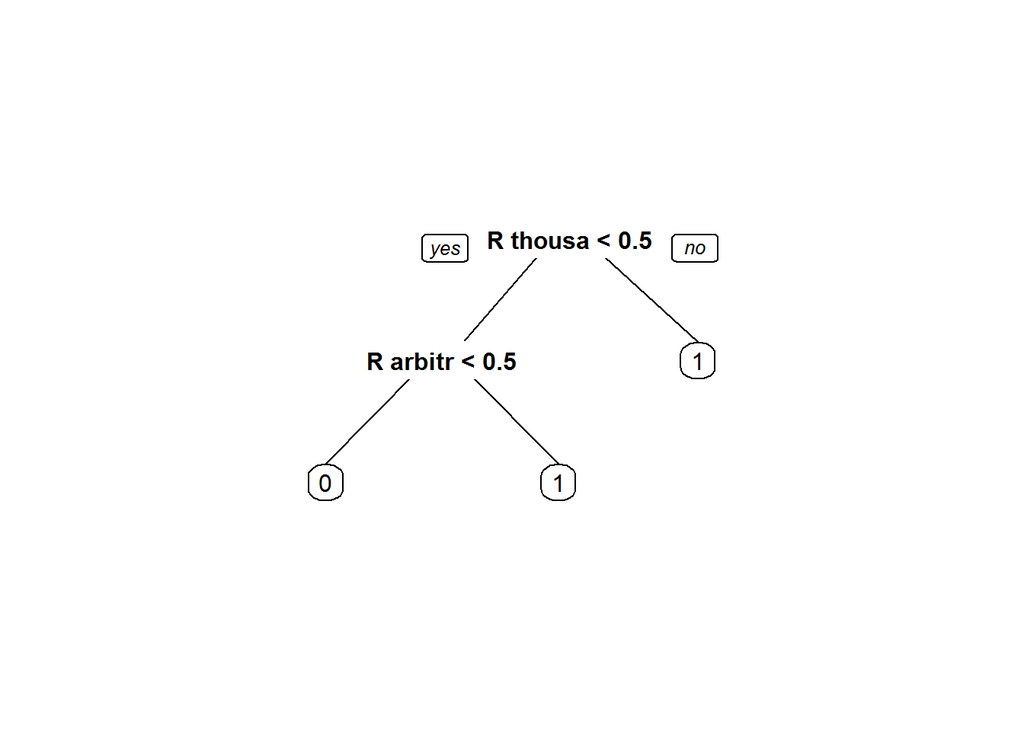

```r
library(rpart.plot)
vandalCART <- rpart(Vandal ~ ., data=train, method="class")
prp(vandalCART) #I do not understand this tree...
```

```r
# Evaluate the performance of the model
predictCART = predict(vandalCART, newdata=test, type="class") #1st argument actual outcome, 2nd our predictions

t1 <- table(test$Vandal, predictCART)
t1
```

```
##    predictCART
##       0   1
##   0 618   0
##   1 533  12
```

```r
accuracy <- sum(diag(t1))/margin.table(t1)
accuracy #0.5417025. Just a little better thant the baseline
```

```
## [1] 0.5417025
```

# Problem specific knowledge

We weren’t able to improve on the baseline using the raw textual information. More specifically, the words themselves were not useful. There are other options though, and in this section we will try two techniques - identifying a key class of words, and counting words.

The key class of words we will use are website addresses. “Website addresses” (also known as URLs - Uniform Resource Locators) are comprised of two main parts. An example would be “http://www.google.com”. The first part is the protocol, which is usually “http” (HyperText Transfer Protocol). The second part is the address of the site, e.g. “www.google.com”. We have stripped all punctuation so links to websites appear in the data as one word, e.g. “httpwwwgooglecom”. We hypothesize that given that a lot of vandalism seems to be adding links to promotional or irrelevant websites, the presence of a web address is a sign of vandalism.

We can search for the presence of a web address in the words added by searching for “http” in the Added column. The grepl function returns TRUE if a string is found in another string, e.g.

grepl(“cat”,“dogs and cats”,fixed=TRUE) # TRUE

grepl(“cat”,“dogs and rats”,fixed=TRUE) # FALSE

Create a copy of your dataframe from the previous question:

wikiWords2 = wikiWords

Make a new column in wikiWords2 that is 1 if “http” was in Added:

wikiWords2$HTTP = ifelse(grepl("http",wiki$Added,fixed=TRUE), 1, 0)

Based on this new column, how many revisions added a link?

```r
wikiWords2 <- wikiWords
wikiWords2$HTTP <- ifelse(grepl("http",wiki$Added,fixed=TRUE), 1, 0)
table(wikiWords2$HTTP)
```

```
##
##    0    1
## 3659  217
```

## Problem specific knowledge

In problem 1.5, you computed a vector called “spl” that identified the observations to put in the training and testing sets. Use that variable (do not recompute it with sample.split) to make new training and testing sets:

wikiTrain2 = subset(wikiWords2, spl==TRUE)

wikiTest2 = subset(wikiWords2, spl==FALSE)

Then create a new CART model using this new variable as one of the independent variables.

What is the new accuracy of the CART model on the test set, using a threshold of 0.5?

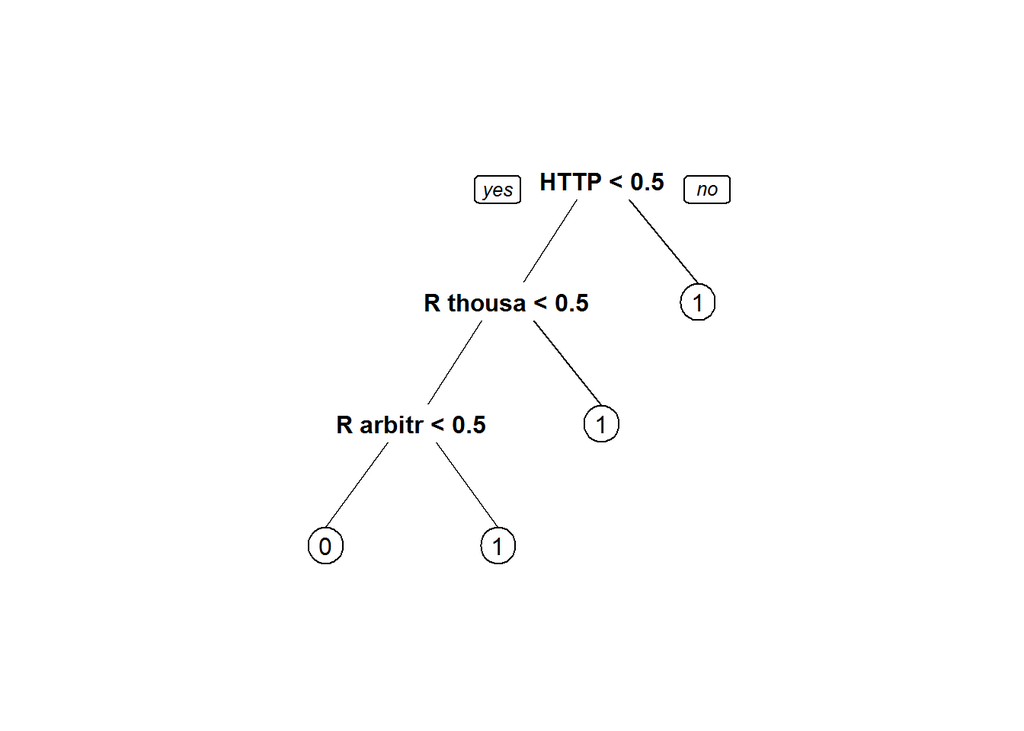

```r
wikiTrain2 = subset(wikiWords2, spl==TRUE)
wikiTest2 = subset(wikiWords2, spl==FALSE)
#Create CART model with wikiWords2$HTTP
wikiCART2 <- rpart(Vandal ~ ., data = wikiTrain2, method = "class")
prp(wikiCART2)
```

```r
#Prediction and accuracy in the test set
pred2 = predict(wikiCART2, newdata=wikiTest2, method="class")
pred.prob2 = pred2[,2]
t1 <- table(wikiTest2$Vandal, pred.prob2 >= 0.5)
t1
```

```
##
##     FALSE TRUE
##   0   609    9
##   1   488   57
```

```r
accuracy <- sum(diag(t1))/margin.table(t1)
accuracy #0.5726569
```

```
## [1] 0.5726569
```

Another possibility is that the number of words added and removed is predictive, perhaps more so than the actual words themselves. We already have a word count available in the form of the document-term matrices (DTMs).

Sum the rows of dtmAdded and dtmRemoved and add them as new variables in your data frame wikiWords2 (called NumWordsAdded and NumWordsRemoved) by using the following commands:

```r
wikiWords2$NumWordsAdded = rowSums(as.matrix(dtmAdded))
wikiWords2$NumWordsRemoved = rowSums(as.matrix(dtmRemoved))
#What is the average number of words added?
summary(wikiWords2$NumWordsAdded)
```

```
##    Min. 1st Qu.  Median    Mean 3rd Qu.    Max.
##    0.00    0.00    1.00    4.05    3.00  259.00
```

In problem 1.5, you computed a vector called “spl” that identified the observations to put in the training and testing sets. Use that variable (do not recompute it with sample.split) to make new training and testing sets with wikiWords2. Create the CART model again (using the training set and the default parameters).

What is the new accuracy of the CART model on the test set?

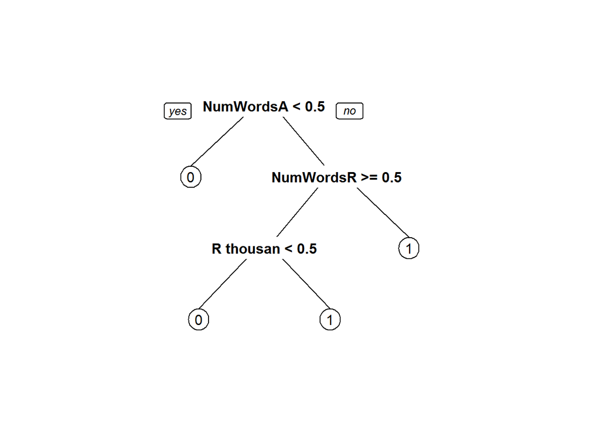

```r
wikiTrain3 = subset(wikiWords2, spl==TRUE)
wikiTest3 = subset(wikiWords2, spl==FALSE)
#Create CART model with new variables( we have now http, and NumWordsAdded and Removed)
wikiCART3 <- rpart(Vandal ~ ., data = wikiTrain3, method = "class")
prp(wikiCART3)
```

```r
#Prediction and accuracy in the test set
pred3 = predict(wikiCART3, newdata=wikiTest3, method="class")
pred.prob3 = pred3[,2]
t1 <- table(wikiTest3$Vandal, pred.prob3 >= 0.5)
t1
```

```
##
##     FALSE TRUE
##   0   514  104
##   1   297  248
```

```r
accuracy <- sum(diag(t1))/margin.table(t1)
accuracy # 0.6552021 Now it has improved!!
```

```
## [1] 0.6552021
```